# Essercitazione 4 – 28 Nov 2025

source ~/rise_env/bin/activate python -m jupyter notebook

## Esercizio 4.1

Sia data la funzione di variabile complessa

$$ f(z) = \sin z. $$

a. **Sviluppare** la funzione in **serie di Taylor** attorno ai punti $$ z_k = \pi k, \qquad k \in \mathbb{Z}. $$

b. **Determinare** il **raggio di convergenza** della serie ottenuta.

c. **Studiare la singolarità all’infinito** della funzione $ \sin z $.

d. **Indicare la natura** delle singolarità al finito e all’infinito.

### a. Serie di Taylor di $ \sin(z) $ attorno a $ ( z_k = \pi k ) $

Vogliamo sviluppare $ f(z) = \sin z $ in serie di Taylor attorno ai punti $ z_k = \pi k, \qquad k \in \mathbb{Z}. $

#### 1. Formula di Taylor

Per una funzione olomorfa, tutto il lavoro consiste nel calcolare le derivate.

$$ \sin z = \sum_{n=0}^{\infty} \frac{\sin^{(n)}(z_k)}{n!}\,(z - z_k)^n. $$

#### 2. Derivate successive di $ \sin z $

Le derivate seguono il ciclo:

$$ \sin z,\ \cos z,\ -\sin z,\ -\cos z,\ \sin z,\dots $$

Valutandole in $z_k = \pi k $

$$ \sin(\pi k) = 0, \qquad \cos(\pi k) = (-1)^k. $$

Da cui: $$ \sin(z_k)=0,\qquad \sin'(z_k)=(-1)^k,\qquad \sin''(z_k)=0,\qquad \sin^{(3)}(z_k)=(-1)^{k+1}, \dots $$

In generale: $$ \sin^{(2m)}(z_k)=0, \qquad \sin^{(2m+1)}(z_k)=(-1)^{k+m}. $$

Troviamo

$$ \boxed{ \sin z = (-1)^k \sum_{m=0}^{\infty} \frac{(-1)^m}{(2m+1)!}\, (z - z_k)^{2m+1}} $$

Questa è la serie di Taylor di $\sin z $ttorno a $k = \pi k $

```python
import sympy as sp
z = sp.symbols('z')

taylor= sp.series(sp.sin(z), z, 0, 10)
taylor
```

$\displaystyle z - \frac{z^{3}}{6} + \frac{z^{5}}{120} - \frac{z^{7}}{5040} + \frac{z^{9}}{362880} + O\left(z^{10}\right)$

### b. Raggio di convergenza della serie di Taylor di $ \sin z $ attorno a $ z_k $

Abbiamo ottenuto lo sviluppo $$ \sin z = (-1)^k \sum_{m=0}^{\infty} \frac{(-1)^m}{(2m+1)!}\, (z - z_k)^{2m+1}, \qquad z_k = \pi k. $$

Vogliamo determinare il **raggio di convergenza** $R$ di questa serie.

#### Funzione intera e singolarità al finito

La funzione $\sin z $ è una funzione **intera**, cioè:

- è olomorfa su tutto il piano complesso $\mathbb{C} $
- non ha singolarità al finito.

In generale, per una serie di Taylor di una funzione olomorfa attorno a un punto $z_0$ il raggio di convergenza $ R $ è dato dalla distanza di $z_0$ dalla singolarità finita più vicina di $f$.

Nel nostro caso:

- $ f(z) = \sin z $ **non ha singolarità al finito**,
- quindi non esiste alcun punto $z \in \mathbb{C} $ dove $ \sin (z) $ smette di essere olomorfa.

#### Conclusione sul raggio di convergenza

Poiché non ci sono singolarità finite, il raggio di convergenza è infinito: $$ \boxed{R = +\infty.} $$

Questo significa che la serie di Taylor di $ \sin z $ attorno a $ z_k = \pi k $ converge per ogni $ z \in \mathbb{C} $.

### c. Singolarità all’infinito della funzione $ \sin z $

opzione 1: Guardiamo la serie di Taylor

Per studiare la natura della singolarità all’infinito di una funzione olomorfa $f(z)$ si considera $$ w = \frac{1}{z}, \qquad g(w) = f\!\left(\frac{1}{w}\right). $$

Il comportamento di $g(w)$ in $w=0$ determina la natura della singolarità di $f$ in $z=\infty$.

Nel nostro caso: $$ g(w) = \sin\!\left(\frac{1}{w}\right). $$

### Serie di Laurent di $\sin\!\left(\frac{1}{w}\right)$ attorno a $w=0$

Partendo dalla serie di Taylor di $\sin z$, $$ \sin z = \sum_{n=0}^{\infty} \frac{(-1)^n}{(2n+1)!}\, z^{\,2n+1}, $$ sostituiamo $z = \frac{1}{w}$.

Otteniamo la serie di Laurent $$ \sin\!\left(\frac{1}{w}\right) = \sum_{n=0}^{\infty} \frac{(-1)^n}{(2n+1)!}\, \left(\frac{1}{w}\right)^{2n+1}. $$

La presenza di **infiniti termini di ordine negativo**  
($w^{-1}, w^{-3}, w^{-5}, \dots$) dimostra che $w=0$ è una **singolarità essenziale**.

opzione2: Studiamo $g(w)$ quando $w \to 0$ lungo direzioni diverse.

### 1. Comportamento lungo direzioni reali

Se $w \in \mathbb{R}$ e $w \to 0$, allora $$ \frac{1}{w} \to \pm\infty, $$ e quindi $$ \sin\!\left(\frac{1}{w}\right) $$ oscilla tra $-1$ e $1$ senza ammettere limite.

### 2. Comportamento lungo l’asse immaginario

Se $w = i y$ con $y\to 0$, allora $$ \frac{1}{w} = -\frac{i}{y}. $$

Usando l’identità valida dalla serie di Taylor, $$ \sin(it)=i\sinh(t), $$ si ottiene $$ \sin\!\left(-\frac{i}{y}\right) = -i\sinh\!\left(\frac{1}{y}\right), $$ e quindi $$ \left|\sin\!\left(\frac{1}{w}\right)\right| \to \infty. $$

Lungo questa direzione la funzione **diverge**.

### 3. Conclusione

Vicino a $w=0$, la funzione $g(w)=\sin(1/w)$ mostra:

- oscillazioni illimitate lungo direzioni reali,
- divergenze lungo direzioni immaginarie,
- comportamento altamente irregolare (teoremi di Casorati–Weierstrass e Picard).

Questa è la firma caratteristica di una **singolarità essenziale**.

Pertanto: $$ \boxed{ z = \infty \text{ è una singolarità essenziale per } \sin z. } $$

### Tabella riassuntiva – Esercizio 1 (funzione $ \sin z $)

| Aspetto | Risultato | Note |
| --- | --- | --- |
| **Punti di sviluppo** | $ z_k = \pi k $, $k \in \mathbb{Z}$ | Zeri della funzione seno |
| **Sviluppo di Taylor** attorno a $ z_k $ | $ \displaystyle \sin z = (-1)^k \sum_{m=0}^{\infty} \frac{(-1)^m}{(2m+1)!} (z - z_k)^{2m+1} $ | Solo potenze dispari; zero semplice |
| **Primi termini** | $ \displaystyle \sin z = (-1)^k \left[ (z - z_k) - \frac{(z - z_k)^3}{3!} + \frac{(z - z_k)^5}{5!} - \cdots \right] $ | Derivato usando solo Taylor |
| **Ordine dello zero in $z_k$** | Zero semplice | Perché il termine dominante è $(z-z_k)$ |
| **Derivate in $z_k$** | $ \sin^{(2m)}(z_k) = 0 $, $ \sin^{(2m+1)}(z_k) = (-1)^{k+m} $ | Derivazione ciclica di periodo 4 |
| **Raggio di convergenza** | $ R = +\infty $ | La funzione è intera (nessuna singolarità al finito) |
| **Singolarità al finito** | Nessuna | $\sin z$ è intera |
| **Singolarità all’infinito** | Singolarità essenziale | Dimostrato usando $ g(w)=\sin(1/w) $ |
| **Comportamento di $ \sin(1/w) $ vicino a 0** | Oscillazioni e divergenza direzionale | Conclusione: essenziale |

### Riassunto finale

$$ \boxed{ \sin z \text{ è intera, ha zeri semplici in } z_k=\pi k,\ \text{e una singolarità essenziale in } z=\infty. } $$

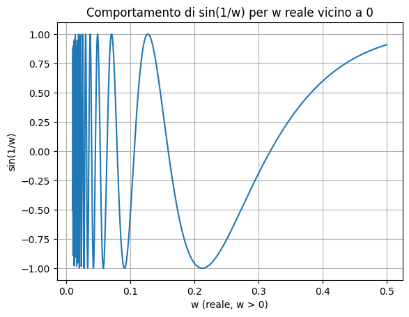

```python
#codigo 4.1

import sympy as sp
import numpy as np
import matplotlib.pyplot as plt

# w reale > 0 piccolo: sin(1/w) oscilla
w_real = np.linspace(0.01, 0.5, 2000)
f_real = np.sin(1.0 / w_real)

plt.figure()
plt.plot(w_real, f_real)
plt.xlabel("w (reale, w > 0)")
plt.ylabel("sin(1/w)")
plt.title("Comportamento di sin(1/w) per w reale vicino a 0")
plt.grid(True)
plt.show()
```

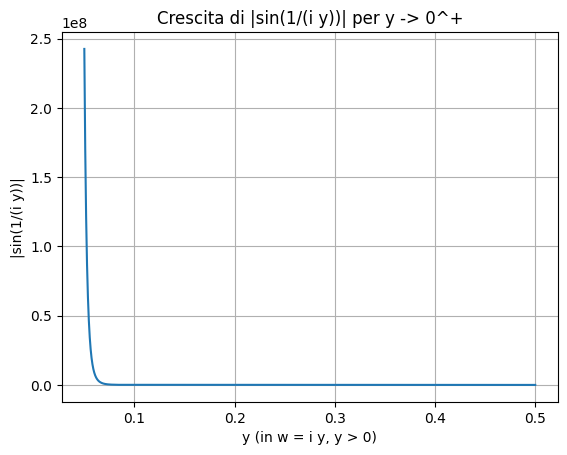

```python
# w = i y, y reale piccolo: |sin(1/(i y))| cresce
y_vals = np.linspace(0.5, 0.05, 500)  # y > 0 che tende a 0
w_imag = 1j * y_vals
f_imag = np.sin(1.0 / w_imag)
mod_imag = np.abs(f_imag)

plt.figure()
plt.plot(y_vals, mod_imag)
plt.xlabel("y (in w = i y, y > 0)")
plt.ylabel("|sin(1/(i y))|")
plt.title("Crescita di |sin(1/(i y))| per y -> 0^+")
plt.grid(True)
plt.show()
```

### Interpretazione grafica del comportamento di $\sin(1/w)$ vicino a $w=0$

I grafici precedenti mostrano in modo molto chiaro la natura della singolarità di $$ g(w) = \sin\!\left(\frac{1}{w}\right) $$ in $w=0$ (che corrisponde alla singolarità di $\sin z$ in $z=\infty$).

## 1. Comportamento lungo l'asse reale

Nel primo grafico abbiamo preso $w \in \mathbb{R}^+$ e $w \to 0^+$.

L'argomento $1/w$ tende a $+\infty$ e quindi $$ \sin\!\left(\frac{1}{w}\right) $$ oscilla sempre più rapidamente tra $-1$ e $1$.

- L'ampiezza rimane limitata.
- La frequenza delle oscillazioni diventa infinita.
- **Non esiste limite.**

Questa è una tipica manifestazione di comportamento “caotico” vicino a una singolarità essenziale.

## 2. Comportamento lungo la direzione immaginaria

Nel secondo grafico prendiamo $w = i y$ con $y>0$ e $y \to 0$.

In questo caso: $$ \sin\!\left(\frac{1}{iy}\right) = -i\,\sinh\!\left(\frac{1}{y}\right), $$ e quindi il modulo cresce come $$ |\sinh(1/y)| \to \infty. $$

Quindi lungo questo cammino:

- la funzione **diverge**,
- il modulo cresce in modo **esponenziale**.

## 3. Conclusione: singolarità essenziale

Mettiamo insieme i due comportamenti:

- lungo direzioni reali: **oscillazioni senza limite**, ma sempre finite;
- lungo direzioni immaginarie: **esplosione verso infinito**;
- lungo altre direzioni complesse: combinazioni di oscillazione e crescita.

Questo è esattamente il comportamento previsto dai teoremi di  
**Casorati–Weierstrass** e **Picard** per una singolarità essenziale.

In particolare: $$ \boxed{ w = 0 \ \Longleftrightarrow\ z = \infty \quad\text{è una singolarità essenziale di } \sin z. } $$

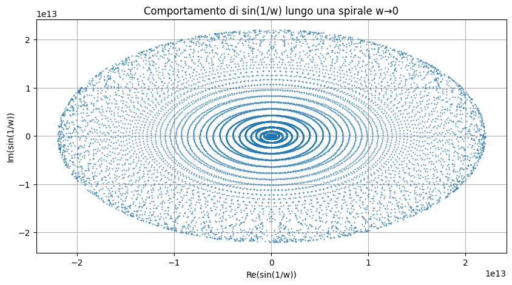

```python
import numpy as np
import matplotlib.pyplot as plt


t = np.linspace(0.1, 20*np.pi, 500000)
r = 0.5 - (t / (20*np.pi)) * 2

# Espiral en el plano w: r(t) * e^{i t}
w = r * np.exp(1j * t)
f = np.sin(1.0 / w)

plt.figure(figsize=(10,5))
plt.plot(np.real(f), np.imag(f), '.', ms=1)
plt.xlabel("Re(sin(1/w))")
plt.ylabel("Im(sin(1/w))")
plt.title("Comportamento di sin(1/w) lungo una spirale w→0")
plt.grid(True)
plt.show()
```

## Esercizio 4.2

Studiare la funzione $$ f(z) = \frac{1}{\sin z} $$ sia al finito che all’infinito.

Calcolare tutti i residui ai punti singolari finiti.

### Soluzione – Esercizio 4.2

### 1. Singolarità al finito

Gli zeri di $\sin z$ sono $$ z_k = \pi k, \qquad k \in \mathbb{Z}. $$

Dall’esercizio 1.1 sappiamo che si tratta di **zeri semplici**, perché lo sviluppo di Taylor attorno a $z_k$ è $$ \sin z = (-1)^k (z - z_k) + O\big((z - z_k)^3\big). $$

Se $g$ ha uno zero semplice in $z_k$, allora $1/g$ ha un **polo semplice** in $z_k$.  
Quindi $1/\sin z$ ha **poli semplici** in tutti i punti $z_k = \pi k$ e nessun’altra singolarità al finito.

$$ \boxed{ \text{Singolarità finite di } \frac{1}{\sin z}: \text{ poli semplici in } z_k = \pi k,\ k\in\mathbb{Z}. } $$

## 2. Residui ai punti singolari finiti

Per un polo semplice di $\dfrac{g(z)}{h(z)}$ in $z_0$ con $h(z_0)=0$ e $h'(z_0)\neq 0$, $$ \operatorname{Res}\!\left(\frac{g}{h}, z_0\right) = \frac{g(z_0)}{h'(z_0)}. $$

Nel nostro caso: $$ g(z) = 1, \qquad h(z) = \sin z, \qquad h'(z) = \cos z. $$

Poiché $$ \cos(\pi k) = (-1)^k, $$ si ha $$ \operatorname{Res}\!\left(\frac{1}{\sin z}, \pi k\right) = \frac{1}{\cos(\pi k)} = \frac{1}{(-1)^k} = (-1)^k. $$

Quindi $$ \boxed{ \operatorname{Res}\!\left(\frac{1}{\sin z}, \pi k\right) = (-1)^k,\qquad k\in\mathbb{Z}. } $$

Vogliamo dimostrare che se

- $g(z_0) = 0$,
- $g'(z_0) \neq 0$ (quindi $z_0$ è uno *zero semplice*),

allora la funzione
$$ f(z) = \frac{1}{g(z)} $$ ha un *polo semplice* in $z_0$ e il suo residuo vale $$ \operatorname{Res}\!\left( \frac{1}{g(z)},\, z_0 \right) = \frac{1}{g'(z_0)}. $$

### 2. Inversione dell'espressione

Consideriamo $$ f(z) = \frac{1}{g(z)} = \frac{1}{(z-z_0)\,\big[ g'(z_0) + O(z-z_0) \big]}. $$

Separiamo i fattori: $$ f(z) = \frac{1}{z - z_0}\cdot \frac{1}{g'(z_0) + O(z-z_0)}. $$

Il secondo fattore è analitico in $z_0$ e vale $$ \frac{1}{g'(z_0)} + O(z - z_0). $$

### 4. Residuo

Per definizione, il residuo è il coefficiente del termine $\frac{1}{z - z_0}$: $$ \boxed{ \operatorname{Res}\!\left(\frac{1}{g(z)}, z_0\right) = \frac{1}{g'(z_0)}. } $$

### Applicazione al caso $f(z) = 1/\sin z$

Poiché

- $g(z) = \sin z$,
- $z_k = \pi k$,
- $g'(z_k) = \cos(\pi k) = (-1)^k \neq 0$,

otteniamo: $$ \boxed{ \operatorname{Res}\!\left(\frac{1}{\sin z},\, \pi k\right) = (-1)^k. } $$

### 3. Singolarità all’infinito

Per studiare la singolarità all’infinito consideriamo il cambio di variabile $$ w = \frac{1}{z}, \qquad z = \frac{1}{w}, $$ e definiamo $$ g(w) = f\!\left(\frac{1}{w}\right) = \frac{1}{\sin(1/w)}. $$

Gli zeri di $\sin(1/w)$ sono dati da $$ \sin\!\left(\frac{1}{w}\right) = 0 \quad\Longleftrightarrow\quad \frac{1}{w} = \pi k \quad\Longleftrightarrow\quad w_k = \frac{1}{\pi k}, \qquad k\in\mathbb{Z}\setminus\{0\}. $$

In ciascun $w_k$, la funzione $g(w) = 1/\sin(1/w)$ ha un **polo semplice**.  
I punti $w_k$ si accumulano in $w = 0$.

$$ \boxed{ z = \infty \text{ è una singolarità essenziale per } \frac{1}{\sin z}. } $$

### 4. Riassunto

- Singolarità finite: poli semplici in $z_k = \pi k$, $k\in\mathbb{Z}$.
- Residui: $\operatorname{Res}(1/\sin z,\ \pi k) = (-1)^k$.
- All’infinito: singolarità essenziale.

$$ \boxed{ \frac{1}{\sin z} \text{ ha soli poli semplici al finito e una singolarità essenziale all’infinito.} } $$

# Importante

### Tabella – Relazione tra singolarità di $f$ e di $1/f$

| Tipo di comportamento di $f$ in $z_0$ | Comportamento di $1/f$ in $z_0$ | Commento |
| --- | --- | --- |
| $f(z_0) \neq 0$ (punto regolare) | Punto regolare | $1/f$ è olomorfa perché non stiamo dividendo per $0$. |
| Zero semplice di $f$ in $z_0$ | Polo semplice di $1/f$ | Se $f(z) = (z-z_0) f'(z_0) + \dots$ con $f'(z_0)\neq 0$, allora $1/f(z) \sim \dfrac{1}{f'(z_0)}\dfrac{1}{z-z_0}$. |
| Zero di ordine $m$ di $f$ | Polo di ordine $m$ di $1/f$ | Se $f(z)\sim (z-z_0)^m g(z)$ con $g(z_0)\neq 0$, allora $1/f(z)\sim (z-z_0)^{-m}$. |
| Polo di ordine $m$ di $f$ | Zero di ordine $m$ di $1/f$ (punto regolare) | Se $f(z)\sim (z-z_0)^{-m}$, allora $1/f(z)\sim (z-z_0)^m$ è olomorfa. |
| Singolarità removibile di $f$ con $f(z_0)\neq 0$ | Punto regolare di $1/f$ | Estendendo $f$ in modo olomorfo, $1/f$ resta olomorfa e finita. |
| Singolarità removibile di $f$ con $f(z_0)=0$ | Polo di $1/f$ | L’estensione di $f$ ha uno zero in $z_0$, quindi $1/f$ ha un polo. |
| Singolarità essenziale di $f$ | Singolarità essenziale di $1/f$ | Picard: vicino a una essenziale $f$ assume tutti i valori (tranne al più uno) infinite volte, quindi $1/f$ ha comportamento altrettanto “caotico”. |

### Esempi collegati agli Esercizi 1 e 2

| Funzione | Punto | Tipo per $f$ | Tipo per $1/f$ |
| --- | --- | --- | --- |
| $f(z) = \sin z$ | $z_k = \pi k$ | Zero semplice | Polo semplice di $1/\sin z$ in $z_k$ |
| $f(z) = \sin z$ | $\infty$ | Singolarità essenziale | Singolarità essenziale di $1/\sin z$ in $\infty$ |

### Teorema di Picard (forma qualitativa)

**Picard (grande teorema).**  
Sia $f$ olomorfa in un intorno puntato di una singolarità isolata $z_0$.

Se $z_0$ è una **singolarità essenziale**, allora:

- in ogni intorno di $z_0$ la funzione $f$ assume **tutti** i valori complessi,
- con **al più una eccezione**,
- e ogni valore (non eccezionato) è assunto **infinitamente molte volte**.

In particolare, il comportamento vicino a una singolarità essenziale è “massimamente caotico”:

- $f$ non può avere limite finito,
- $f$ non può comportarsi come un polo (tipo potenza),
- i valori di $f$ si “densificano” sul piano complesso.

**Applicazione agli esercizi:**

- Per $f(z) = \sin z$ in $z = \infty$: la funzione $\sin(1/w)$ in $w=0$ assume valori molto diversi (oscilla, diverge, ecc.) $\Rightarrow$ singolarità essenziale.
- Per $f(z) = 1/\sin z$ in $z = \infty$: la funzione $1/\sin(1/w)$ ha infiniti poli che si accumulano in $w=0$ $\Rightarrow$ di nuovo singolarità essenziale.

### Esempi tipici

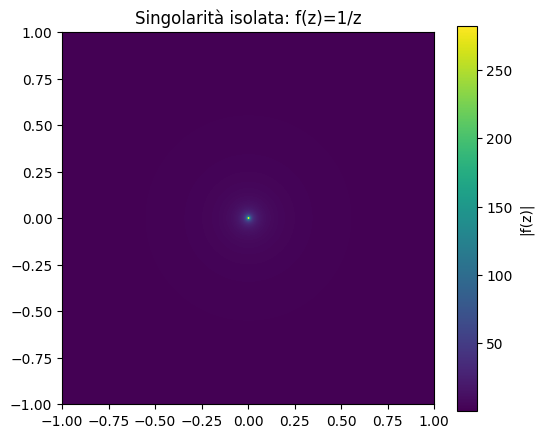

```python
import numpy as np
import matplotlib.pyplot as plt

# Malla cercana al origen
x = np.linspace(-1, 1, 400)
y = np.linspace(-1, 1, 400)
X, Y = np.meshgrid(x, y)
Z = X + 1j*Y

# Evitamos z=0
Z[np.abs(Z) < 1e-3] = np.nan

f = 1/Z

plt.figure(figsize=(6,5))
plt.imshow(np.abs(f), extent=[-1,1,-1,1], origin='lower')
plt.title("Singolarità isolata: f(z)=1/z")
plt.colorbar(label="|f(z)|")
plt.show()
```

[figure not shown]

```python
import numpy as np
import matplotlib.pyplot as plt

x = np.linspace(-1, 1, 400)
y = np.linspace(-1, 1, 400)
X, Y = np.meshgrid(x, y)
Z = X + 1j*Y

Z[np.abs(Z) < 1e-3] = np.nan

f = np.exp(1/Z)

plt.figure(figsize=(6,5))
plt.imshow(np.abs(f), extent=[-1,1,-1,1], origin='lower')
plt.title("Singolarità essenziale isolata: f(z)=e^{1/z}")
plt.colorbar(label="|f(z)|")
plt.show()
```

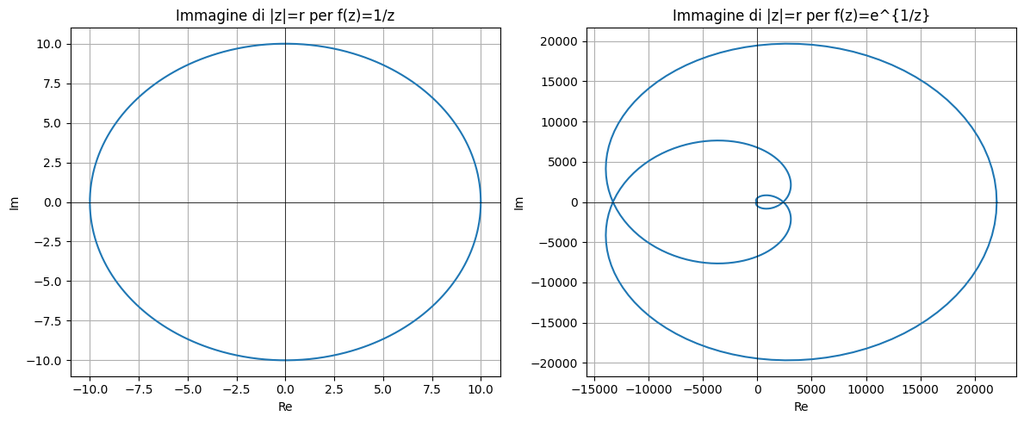

```python
import numpy as np
import matplotlib.pyplot as plt

r = 0.1
theta = np.linspace(0, 2*np.pi, 1000)
z = r * np.exp(1j * theta)

f_polo = 1 / z
f_ess  = np.exp(1 / z)

plt.figure(figsize=(12,5))

# 1/z
plt.subplot(1,2,1)
plt.plot(np.real(f_polo), np.imag(f_polo))
plt.xlabel("Re")
plt.ylabel("Im")
plt.title("Immagine di |z|=r per f(z)=1/z")
plt.axhline(0, color="black", linewidth=0.5)
plt.axvline(0, color="black", linewidth=0.5)
plt.grid(True)

# e^{1/z}
plt.subplot(1,2,2)
plt.plot(np.real(f_ess), np.imag(f_ess))
plt.xlabel("Re")
plt.ylabel("Im")
plt.title("Immagine di |z|=r per f(z)=e^{1/z}")
plt.axhline(0, color="black", linewidth=0.5)
plt.axvline(0, color="black", linewidth=0.5)
plt.grid(True)

plt.tight_layout()
plt.show()
```

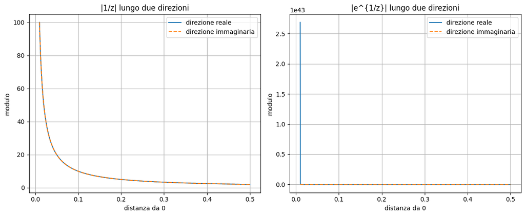

```python
import numpy as np
import matplotlib.pyplot as plt

x = np.linspace(0.01, 0.5, 1000)
z_real = x
z_imag = 1j * x

f_polo_real = 1 / z_real
f_polo_imag = 1 / z_imag

f_ess_real = np.exp(1 / z_real)
f_ess_imag = np.exp(1 / z_imag)

plt.figure(figsize=(12,5))

# Polo 1/z: módulo es 1/|z| en ambas direcciones
plt.subplot(1,2,1)
plt.plot(x, np.abs(f_polo_real), label="direzione reale")
plt.plot(x, np.abs(f_polo_imag), "--", label="direzione immaginaria")
plt.title("|1/z| lungo due direzioni")
plt.xlabel("distanza da 0")
plt.ylabel("modulo")
plt.legend()
plt.grid(True)

# Essenziale e^{1/z}: comportamiento muy distinto
plt.subplot(1,2,2)
plt.plot(x, np.abs(f_ess_real), label="direzione reale")
plt.plot(x, np.abs(f_ess_imag), "--", label="direzione immaginaria")
plt.title("|e^{1/z}| lungo due direzioni")
plt.xlabel("distanza da 0")
plt.ylabel("modulo")
plt.legend()
plt.grid(True)

plt.tight_layout()
plt.show()
```

### Confronto grafico tra una singolarità isolata (polo) e una singolarità essenziale isolata

Per distinguere chiaramente un **polo** da una **singolarità essenziale**, è molto utile osservare il comportamento della funzione su una **circonferenza** attorno al punto singolare.

Consideriamo il disco $|z| = r$ con $r$ molto piccolo.

## 1. Caso del polo: $f(z) = 1/z$

Sostituendo $z = r e^{i\theta}$ si ottiene $$ f(z) = \frac{1}{r e^{i\theta}} = \frac{1}{r} e^{-i\theta}. $$

Quindi l’immagine della circonferenza è **ancora una circonferenza**, semplicemente ingrandita di un fattore $1/r$. Il comportamento è **regolare**, uniforme in tutte le direzioni.

- Nessuna oscillazione imprevedibile
- Nessuna dipendenza speciale dalla direzione
- La funzione cresce come $1/r$ e basta

Un grafico nel piano complesso mostra una curva chiusa regolare.

## 2. Caso della singolarità essenziale: $f(z) = e^{1/z}$

Sostituendo $z = r e^{i\theta}$ otteniamo $$ f(z) = \exp\!\left(\frac{1}{r} e^{-i\theta}\right) = \exp\!\left(\frac{\cos\theta}{r}\right) \, \exp\!\left(-i\frac{\sin\theta}{r}\right). $$

La funzione dipende in modo **estremamente sensibile** dalla direzione $\theta$:

- per $\theta = 0$, il modulo esplode:
  $$|f(z)| = e^{1/r} \to +\infty$$
- per $\theta = \pi$, il modulo tende a $0$:
  $$|f(z)| = e^{-1/r} \to 0$$
- per $\theta = \pi/2$, il modulo resta $1$:
  $$|f(z)| = e^0 = 1$$
- per altre direzioni il comportamento è misto e molto irregolare

L’immagine della circonferenza nel piano complesso **non è più una curva semplice**,  
ma una traiettoria che si avvolge, si estende e si contrae in modo caotico.

Questo è il comportamento caratteristico di una **singolarità essenziale**.

## 3. Differenza fondamentale

- **Polo** La circonferenza resta una circonferenza: comportamento regolare
- **Essenziale** La circonferenza si deforma in modo caotico: comportamento altamente direzionale

### Conclusione

- Un **polo** si riconosce perché la funzione diverge come $1/r^n$ in tutte le direzioni allo stesso modo.
- Una **singolarità essenziale** si riconosce dal fatto che la funzione può:
  - divergere in alcune direzioni,
  - rimanere limitata in altre,
  - tendere a zero in altre,
  - e oscillare senza limite in altre ancora.

Questo comportamento dipendente dalla direzione è la firma inequivocabile di una singolarità essenziale.

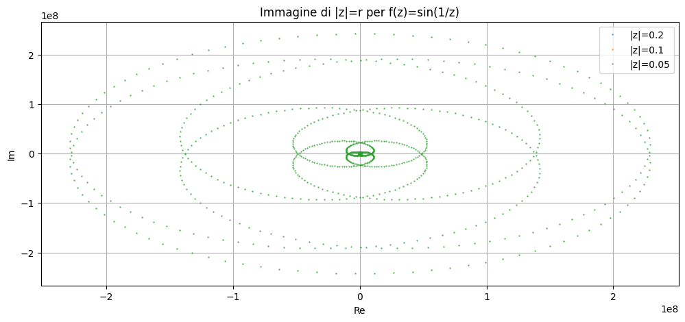

```python
import numpy as np
import matplotlib.pyplot as plt

radii = [0.2, 0.1, 0.05]
theta = np.linspace(0, 2*np.pi, 2000)

plt.figure(figsize=(12,5))

for r in radii:
    z = r * np.exp(1j * theta)
    f = np.sin(1/z)
    plt.plot(np.real(f), np.imag(f), '.', markersize=1, label=f"|z|={r}")

plt.title("Immagine di |z|=r per f(z)=sin(1/z)")
plt.xlabel("Re")
plt.ylabel("Im")
plt.grid(True)
plt.legend()
plt.show()
```

[figure not shown]

```python
import numpy as np
import matplotlib.pyplot as plt

x = np.linspace(-1, 1, 600)
y = np.linspace(-1, 1, 600)
X, Y = np.meshgrid(x, y)
Z = X + 1j*Y

# evitar z=0
Z[np.abs(Z) < 1e-4] = np.nan

f = np.sin(1/Z)

plt.figure(figsize=(6,5))
plt.imshow(np.abs(f), extent=[-1,1,-1,1], origin='lower', cmap="inferno")
plt.title("Singolarità NON isolata: f(z)=sin(1/z)")
plt.colorbar(label="|f(z)|")
plt.show()
```

### Singolarità non isolata: esempio di $f(z)=\sin(1/z)$

La funzione $$ f(z)=\sin\!\left(\frac{1}{z}\right) $$ ha una singolarità in $z=0$ che **non è isolata**.

Infatti: $$ \sin(1/z) = 0 \quad \Leftrightarrow \quad z = \frac{1}{n\pi}, \qquad n\to\infty. $$

### Conclusione

Il punto $z=0$ non può essere:

- un polo,
- una singolarità essenziale isolata,
- né una singolarità removibile.

# Riassunto: Le tre grandi classi di singolarità nel piano complesso

Consideriamo una funzione olomorfa $f(z)$ definita in un intorno puntato di $z_0$. Una singolarità isolata può essere:

1. **Removibile**
2. **Polo** (di ordine finito)
3. **Essenziale**

Se invece esistono infinite singolarità che si accumulano nel punto, allora la singolarità è **non isolata**.

## 1️ Singolarità removibile

### Definizione

$f$ è limitata in un intorno di $z_0$ e si può estendere analiticamente in $z_0$.

### Esempio

$$ f(z)=\frac{\sin z}{z}. $$

In $z=0$ il limite esiste e vale $1$.

### Visualizzazione

Il modulo è regolare e non diverge.

## 2️ Polo (isolato)

### Definizione

$f(z)$ diverge come $$ \frac{1}{(z-z_0)^n} $$ per qualche $n\in\mathbb{N}$.

### Esempio

$$ f(z)=\frac{1}{z}. $$

### Comportamento

- Divergenza uniforme in tutte le direzioni
- L’immagine di un cerchio $|z-z_0|=r$ è un cerchio $\frac{1}{r}$

## 3️ Singolarità essenziale (isolata)

### Definizione

La funzione presenta comportamento altamente irregolare vicino a $z_0$.  
Per il teorema di Casorati–Weierstrass / Picard assume valori arbitrariamente vicini a *tutti* i numeri complessi.

### Esempio

$$ f(z)=e^{1/z}. $$

### Comportamento direzionale

- Lungo alcune direzioni $|f(z)|\to\infty$
- Lungo altre $|f(z)|\to 0$
- Lungo altre ancora $|f(z)|\approx 1$
- Oscillazioni violente

L’immagine del cerchio $|z|=r$ non è una curva semplice, ma una traiettoria contorta.

## 4️ Singolarità NON isolata (accumulo di singolarità)

### Definizione

Ogni disco attorno a $z_0$ contiene **infinitamente molte** singolarità di $f$.

### Esempio canonico

$$ f(z)=\sin\!\left(\frac{1}{z}\right). $$

Gli zeri sono $$ z_n = \frac{1}{n\pi},\qquad n\to\infty, $$ e si **accumulano** in $0$.

### Comportamento

# Tabella riassuntiva finale

| Tipo | Isolata? | Esempio | Comportamento |
| --- | --- | --- | --- |
| Removibile | sì | $\sin z / z$ | limite finito |
| Polo | sì | $1/z$ | divergenza uniforme |
| Essenziale | sì | $e^{1/z}$ | valori arbitrari, comportamento caotico |
| Non isolata | no | $\sin(1/z)$ | accumulo di singolarità |

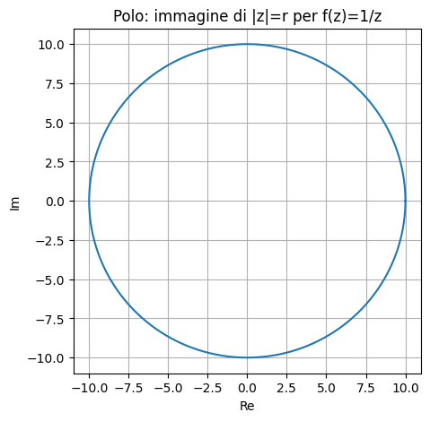

```python
import numpy as np
import matplotlib.pyplot as plt

r = 0.1
theta = np.linspace(0, 2*np.pi, 1000)
z = r * np.exp(1j * theta)
f = 1 / z

plt.figure(figsize=(5,5))
plt.plot(np.real(f), np.imag(f))
plt.title("Polo: immagine di |z|=r per f(z)=1/z")
plt.xlabel("Re")
plt.ylabel("Im")
plt.grid(True)
plt.show()
```

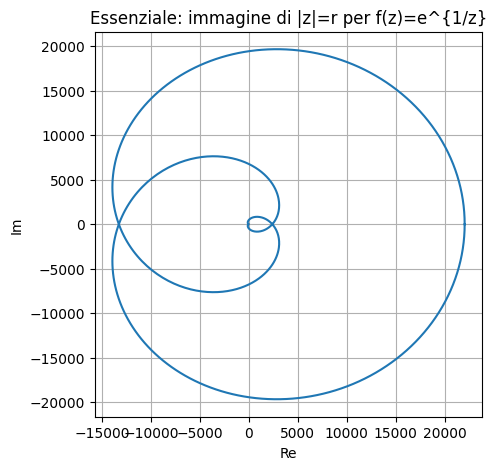

```python
import numpy as np
import matplotlib.pyplot as plt

r = 0.1
theta = np.linspace(0, 2*np.pi, 2000)
z = r * np.exp(1j * theta)
f = np.exp(1/z)

plt.figure(figsize=(5,5))
plt.plot(np.real(f), np.imag(f))
plt.title("Essenziale: immagine di |z|=r per f(z)=e^{1/z}")
plt.xlabel("Re")
plt.ylabel("Im")
plt.grid(True)
plt.show()
```

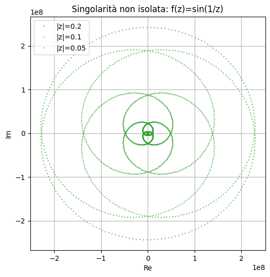

```python
import numpy as np
import matplotlib.pyplot as plt

theta = np.linspace(0, 2*np.pi, 4000)

plt.figure(figsize=(6,6))

for r in [0.2, 0.1, 0.05]:
    z = r * np.exp(1j * theta)
    f = np.sin(1/z)
    plt.plot(np.real(f), np.imag(f), '.', ms=1, label=f"|z|={r}")

plt.title("Singolarità non isolata: f(z)=sin(1/z)")
plt.xlabel("Re")
plt.ylabel("Im")
plt.grid(True)
plt.legend()
plt.show()
```

## Esercizio 4.3 – Enunciato

Studiare la funzione $$ f(z) = \frac{e^{2z}}{(z-1)^3} $$ sia al finito che all’infinito.

Sviluppare la funzione in serie di Laurent attorno a $z=1$ e calcolare il residuo nei punti singolari finiti.

### Soluzione – Esercizio 4.3

### 1. Singolarità al finito

Il numeratore $e^{2z}$ è una funzione intera (olomorfa su tutto $\mathbb{C}$).

L’unico problema è il denominatore $(z-1)^3$.

- In $z=1$ il denominatore si annulla di ordine $3$.
- Il numeratore $e^{2z}$ è diverso da $0$ in $z=1$, infatti $e^{2\cdot 1} = e^2 \neq 0$.

Quindi:

- $z=1$ è un **polo di ordine 3**.
- Non ci sono altre singolarità al finito.

$$ \boxed{ \text{Singolarità al finito: un polo di ordine 3 in } z=1. } $$

### 2. Sviluppo di Laurent attorno a $z=1$

Poniamo $$ w = z - 1 \quad \Longrightarrow \quad z = 1 + w. $$

Allora $$ e^{2z} = e^{2(1+w)} = e^2 e^{2w}. $$

Lo sviluppo di $e^{2w}$ attorno a $w=0$ è la serie di Taylor $$ e^{2w} = \sum_{n=0}^{\infty} \frac{(2w)^n}{n!} = \sum_{n=0}^{\infty} \frac{2^n}{n!} w^n. $$

Sostituendo in $f$: $$ f(z) = \frac{e^{2z}}{(z-1)^3} = \frac{e^2 e^{2w}}{w^3} = e^2 \,\frac{1}{w^3}\sum_{n=0}^{\infty} \frac{2^n}{n!}\,w^n = e^2 \sum_{n=0}^{\infty} \frac{2^n}{n!}\,w^{n-3}. $$

Ritornando a $z-1 = w$, otteniamo la serie di Laurent in forma compatta: $$ \boxed{ f(z) = e^2 \sum_{n=0}^{\infty} \frac{2^n}{n!}\,(z-1)^{\,n-3}. } $$

Esplicitando i primi termini:

- per $n=0$: $e^2 \dfrac{2^0}{0!}(z-1)^{-3} = e^2 (z-1)^{-3}$,
- per $n=1$: $e^2 \dfrac{2^1}{1!}(z-1)^{-2} = 2 e^2 (z-1)^{-2}$,
- per $n=2$: $e^2 \dfrac{2^2}{2!}(z-1)^{-1} = 2 e^2 (z-1)^{-1}$,
- per $n=3$: $e^2 \dfrac{2^3}{3!}(z-1)^{0} = \dfrac{4}{3} e^2$,

ecc.

Quindi: $$ f(z) = e^2 (z-1)^{-3} + 2e^2 (z-1)^{-2} + 2e^2 (z-1)^{-1} + \frac{4}{3}e^2 + \cdots $$

### 3. Calcolo del residuo in $z=1$

Il **residuo** di $f$ in $z=1$ è il coefficiente del termine $(z-1)^{-1}$ nella serie di Laurent.

Dallo sviluppo: $$ f(z) = e^2 \sum_{n=0}^{\infty} \frac{2^n}{n!}(z-1)^{n-3}, $$ il termine con $(z-1)^{-1}$ corrisponde a $$ n-3 = -1 \quad \Longrightarrow \quad n = 2. $$

Il coefficiente è quindi $$ e^2 \cdot \frac{2^2}{2!} = e^2 \cdot \frac{4}{2} = 2 e^2. $$

Dunque: $$ \boxed{ \operatorname{Res}\big(f,1\big) = 2e^2. } $$

*(Volendo, si può confermare con la formula del residuo per un polo di ordine 3, ma lo sviluppo di Laurent è più diretto.)*

### Calcolo del residuo tramite la formula generale per poli di ordine $m$

Nel caso dell’esercizio, la funzione è $$ f(z)=\frac{e^{2z}}{(z-1)^3}, $$ e il punto singolare $z=1$ è un **polo di ordine $3$**.

## Formula generale

Se $f$ ha un polo di ordine $m$ in $z_0$, allora $$ \operatorname{Res}(f,z_0) = \frac{1}{(m-1)!} \lim_{z\to z_0} \frac{d^{\,m-1}}{dz^{\,m-1}} \left[(z-z_0)^m f(z)\right]. $$

Questa formula generalizza il caso del polo semplice, dove compare solo il valore di una funzione analitica in $z_0$.

## Applicazione al caso $f(z)=e^{2z}/(z-1)^3$

Qui

- $z_0 = 1$
- $m = 3$
- $(z-1)^3 f(z) = e^{2z}$ è analitica in tutto il piano.

Dunque $$ \operatorname{Res}(f,1) = \frac{1}{2!} \lim_{z\to 1} \frac{d^{2}}{dz^{2}} \left[e^{2z}\right]. $$

Valutando in $z=1$: $$ \operatorname{Res}(f,1) = \frac{1}{2}\,\big(4e^{2}\big) = 2e^{2}. $$

## Risultato finale

$$ \boxed{ \operatorname{Res}\big(f,1\big)=2e^{2}. } $$

### 4. Singolarità all’infinito

Consideriamo il comportamento di $f(z)$ per $|z|\to\infty$: $$ f(z) = \frac{e^{2z}}{(z-1)^3}. $$

- Il numeratore $e^{2z}$ cresce in modo esponenziale in molte direzioni del piano complesso.
- Il denominatore è solo polinomiale in $z$.

L’esponenziale domina sul polinomio: il modulo di $f(z)$ esplode in molte direzioni, mentre può anche oscillare o diminuire in altre.

Questo comportamento non è compatibile con un semplice **polo all’infinito** (che sarebbe di tipo potenza) né con una singolarità **removibile**.

Il quadro generale è quello di una **singolarità essenziale all’infinito**.

A livello di corso: $$ \boxed{ z = \infty \text{ è una singolarità essenziale per } f(z) = \frac{e^{2z}}{(z-1)^3}. } $$

### Singolarità all’infinito di $f(z)=\dfrac{e^{2z}}{(z-1)^3}$

Per studiare la natura della singolarità in $z=\infty$ si usa il cambio di variabile $$ w = \frac{1}{z}, \qquad z=\frac{1}{w}, $$ e si considera $$ g(w) = f\!\left(\frac{1}{w}\right). $$

Nel nostro caso: $$ g(w) = \frac{e^{2/w}}{\left(\frac{1}{w}-1\right)^3} = e^{2/w}\,\frac{w^3}{(1-w)^3}. $$

La funzione $e^{2/w}$ ha una **singolarità essenziale** in $w=0$, mentre $\dfrac{w^3}{(1-w)^3}$ è analitica in $0$ (con uno zero di ordine $3$).

Espandendo: $$ e^{2/w}=\sum_{n=0}^{\infty}\frac{2^n}{n!}w^{-n}, $$ si ottengono infinitamente molti termini con potenza negativa nell’espansione di $g(w)$.

Quindi $w=0$ è una **singolarità essenziale** per $g$, e dunque $$ \boxed{ z=\infty \text{ è una singolarità essenziale per } f(z)=\frac{e^{2z}}{(z-1)^3}. } $$

Inoltre, il comportamento lungo direzioni diverse conferma che all’infinito la funzione tende a $0$, $\infty$ o oscilla a seconda del cammino, escludendo la possibilità di polo o removibile.

### Riassunto

- Singolarità al finito: solo $z=1$, polo di ordine 3.
- Sviluppo di Laurent attorno a $z=1$: $$ f(z) = e^2 \sum_{n=0}^{\infty} \frac{2^n}{n!}(z-1)^{n-3}. $$
- Residuo: $$ \operatorname{Res}(f,1) = 2e^2. $$
- All’infinito: singolarità essenziale.

### Tabella riassuntiva – Esercizio 1.3

Funzione:
$$ f(z) = \frac{e^{2z}}{(z-1)^3} $$

| Aspetto | Risultato | Note |
| --- | --- | --- |
| Singolarità al finito | $z = 1$ | Polo di ordine $3$ (il numeratore è analitico e non nullo) |
| Sviluppo di Laurent attorno a $z=1$ | $$f(z) = e^2 \sum_{n=0}^{\infty} \frac{2^n}{n!}(z-1)^{\,n-3}$$ | Usato $e^{2z} = e^2 e^{2(z-1)}$ |
| Primi termini | $$e^2(z-1)^{-3} + 2e^2(z-1)^{-2} + 2e^2(z-1)^{-1} + \frac{4}{3}e^2 + \cdots$$ | Esplicitazione |
| Residuo in $z=1$ | $$\operatorname{Res}(f,1) = 2e^2$$ | Coefficiente del termine $(z-1)^{-1}$ |
| Singolarità all’infinito | Singolarità essenziale | L’esponenziale domina il denominatore polinomiale |

### **Riassunto finale**

$$ \boxed{ \begin{aligned} &\text{Unica singolarità al finito: } z=1,\ \text{polo di ordine }3.\\[4pt] &\operatorname{Res}(f,1) = 2e^2.\\[4pt] &\text{La serie di Laurent si ottiene espandendo } e^{2(z-1)}.\\[4pt] &z = \infty \text{ è una singolarità essenziale.} \end{aligned} } $$

## Esercizio 4.4 – Enunciato

Studiare la funzione $$ f(z) = \frac{1}{1 - e^z} $$ sia al finito che all’infinito.

Determinare i punti singolari, la loro natura e calcolare il residuo per $z=0$ (e, se possibile, per tutti i punti singolari finiti).

### Soluzione – Esercizio 4.4

### 1. Singolarità al finito

Le singolarità si trovano dove il denominatore si annulla: $$ 1 - e^z = 0 \quad\Longleftrightarrow\quad e^z = 1. $$

Gli zeri dell’esponenziale: $$ e^z = 1 \quad\Longleftrightarrow\quad z = 2\pi i k,\qquad k \in \mathbb{Z}. $$

Studiamo l’ordine di questi zeri del denominatore.

Poniamo $$ h(z) = 1 - e^z. $$

Allora $$ h'(z) = -e^z, \qquad h'(2\pi i k) = -e^{2\pi i k} = -1 \neq 0. $$

Quindi il denominatore $1 - e^z$ ha zeri **semplici** in $z_k = 2\pi i k$.

Conclusione: in ciascun punto $$ z_k = 2\pi i k,\qquad k\in\mathbb{Z}, $$ la funzione $f(z)$ ha un **polo semplice**.

Non ci sono altre singolarità al finito.

### 2. Residui ai punti singolari finiti

Usiamo la formula per il residuo di $\dfrac{g(z)}{h(z)}$ in un punto dove $h$ ha zero semplice: $$ \operatorname{Res}\!\left(\frac{g}{h}, z_0\right) = \frac{g(z_0)}{h'(z_0)}. $$

Nel nostro caso: $$ g(z) = 1, \qquad h(z) = 1 - e^z, \qquad h'(z) = -e^z. $$

Per $z_k = 2\pi i k$: $$ h'(z_k) = -e^{z_k} = -e^{2\pi i k} = -1. $$

Allora $$ \operatorname{Res}\!\left(\frac{1}{1-e^z}, z_k\right) = \frac{1}{h'(z_k)} = \frac{1}{-1} = -1. $$

In particolare, per $z = 0$ (che corrisponde a $k=0$): $$ \boxed{ \operatorname{Res}\big(f,0\big) = -1. } $$

E più in generale: $$ \boxed{ \operatorname{Res}\big(f, 2\pi i k\big) = -1 \qquad \text{per ogni } k \in \mathbb{Z}. } $$

### 3. Singolarità all’infinito

Per studiare la singolarità all’infinito, poniamo $$ w = \frac{1}{z},\qquad z = \frac{1}{w}, $$ e consideriamo $$ g(w) = f\!\left(\frac{1}{w}\right) = \frac{1}{1 - e^{1/w}}. $$

Osserviamo che:

- La funzione $e^{1/w}$ ha una **singolarità essenziale** in $w=0$ (tipico esempio di esponenziale composta).
- L’equazione $$ e^{1/w} = 1 $$ ha soluzioni $$ \frac{1}{w} = 2\pi i k \quad\Longleftrightarrow\quad w_k = \frac{1}{2\pi i k},\quad k\in\mathbb{Z}\setminus\{0\}, $$ che si **accumulano** in $w=0$.

In ciascun $w_k$ il denominatore $1 - e^{1/w}$ si annulla semplicemente, dunque $g(w)$ ha un **polo semplice** in ogni $w_k$.

I poli $w_k$ si accumulano in $w=0$.

Quindi: $$ \boxed{ w = 0 \text{ è una singolarità essenziale per } g(w) = \frac{1}{1 - e^{1/w}}, } $$ e di conseguenza $$ \boxed{ z = \infty \text{ è una singolarità essenziale per } f(z) = \frac{1}{1 - e^z}. } $$

### 4. Riassunto

- Punti singolari finiti:
  $$ z_k = 2\pi i k,\quad k\in\mathbb{Z} $$
  tutti **poli semplici**.
- Residui: $$ \operatorname{Res}\big(f, 2\pi i k\big) = -1 \quad \text{per ogni } k\in\mathbb{Z}. $$
- All’infinito: **singolarità essenziale**.

$$ \boxed{ \begin{aligned} &f(z) = \frac{1}{1-e^z} \text{ ha poli semplici in } z_k = 2\pi i k;\\[4pt] &\operatorname{Res}(f, z_k) = -1 \ \forall k\in\mathbb{Z};\\[4pt] &z=\infty \text{ è una singolarità essenziale.} \end{aligned} } $$

### Esercizio 4.4 — Soluzione

Studiamo la funzione $$ f(z)=\frac{1}{1-e^z}, $$ sia al finito che all’infinito. Dobbiamo determinare i punti singolari, la loro natura e calcolare il residuo per $z=0$ (e, se possibile, per tutti i punti singolari finiti).

## 1. Punti singolari al finito

Le singolarità si trovano risolvendo $$ 1-e^z = 0 \quad \Longleftrightarrow \quad e^z = 1. $$

Poiché $e^z = 1$ se e solo se $z = 2\pi i k$ con $k\in\mathbb{Z}$, i punti singolari finiti sono: $$ z_k = 2\pi i k, \qquad k\in\mathbb{Z}. $$

Per determinare la natura, poniamo $h(z)=1-e^z$. Allora $$ h(z_k)=0, \qquad h'(z)=-e^z \;\Rightarrow\; h'(z_k)=-1\neq 0. $$

Ogni zero è **semplice**, quindi $f(z)$ ha un **polo semplice** in ciascun punto $z_k$.

## 2. Calcolo dei residui ai punti finiti

Usiamo la formula per la funzione $g(z)/h(z)$ con zero semplice di $h$: $$ \operatorname{Res}\!\left(\frac{g(z)}{h(z)},\,z_0\right) = \frac{g(z_0)}{h'(z_0)}. $$

Nel nostro caso $g(z)=1$ e $h(z)=1-e^z$, dunque $$ \operatorname{Res}\big(f,z_k\big) = \frac{1}{h'(z_k)} = \frac{1}{-1} = -1. $$

In particolare: $$ \boxed{\operatorname{Res}(f,0) = -1} \qquad\text{e}\qquad \boxed{\operatorname{Res}(f,2\pi i k) = -1 \;\text{ per ogni }\; k\in\mathbb{Z}.} $$

## 3. Singolarità all’infinito

Per studiare il comportamento in $z=\infty$ eseguiamo il cambio $$ w = \frac{1}{z}, \qquad z = \frac{1}{w}, $$ e consideriamo $$ g(w) = f\!\left(\frac{1}{w}\right) = \frac{1}{1-e^{1/w}}. $$

La funzione $e^{1/w}$ ha una **singolarità essenziale** in $w=0$ e le soluzioni di $$ 1-e^{1/w}=0 \quad\Longleftrightarrow\quad e^{1/w}=1 $$ sono $$ w_k = \frac{1}{2\pi i k}, \qquad k\neq 0, $$ che si **accumulano** in $0$.

Quindi $g(w)$ ha **infiniti poli semplici** che si avvicinano a $0$, e perciò $w=0$ è una **singolarità non isolata** di $g$.

Di conseguenza: $$ \boxed{ z=\infty \text{ è una singolarità essenziale (non isolata) per } f(z)=\frac{1}{1-e^z}. } $$

## 4. Riassunto

- I punti singolari finiti sono
  $$ z_k = 2\pi i k, \qquad k\in\mathbb{Z}, $$ tutti **poli semplici**.
- I residui sono tutti uguali: $$ \operatorname{Res}(f,z_k) = -1. $$
- In $z=\infty$ la funzione presenta una **singolarità essenziale non isolata**.

### Tabella riassuntiva – Esercizio 4

Funzione: $$ f(z) = \frac{1}{1 - e^z} $$

| Aspetto | Risultato | Note |
| --- | --- | --- |
| Equazione del denominatore | $1 - e^z = 0$ | Singolarità dove $e^z = 1$ |
| Punti singolari finiti | $z_k = 2\pi i k,\ k\in\mathbb{Z}$ | Tutti i multipli interi di $2\pi i$ |
| Tipo di singolarità in $z_k$ | Polo semplice | $1 - e^z$ ha zeri semplici: $(1-e^z)' = -e^z \neq 0$ in $z_k$ |
| Residuo in $z_k$ | $$\operatorname{Res}\big(f, z_k\big) = -1$$ | Formula $\operatorname{Res}(g/h,z_0)=g(z_0)/h'(z_0)$ con $g=1$, $h=1-e^z$ |
| In particolare, residuo in $z=0$ | $$\operatorname{Res}\big(f,0\big) = -1$$ | Corrisponde a $k=0$ |
| Comportamento all’infinito | Singolarità essenziale | Poli di $1/(1-e^{1/w})$ che si accumulano in $w=0$ |

$$ \boxed{ \begin{aligned} &\text{Singolarità finite: poli semplici in } z_k = 2\pi i k,\\[4pt] &\operatorname{Res}(f, z_k) = -1\ \text{per ogni }k\in\mathbb{Z},\\[4pt] &z = \infty \text{ è una singolarità essenziale.} \end{aligned} } $$

## Esercizio 4.5 – Enunciato

Studiare la funzione $$ f(z) = \left( \frac{1}{1 - e^z} \right)^2 $$ sia al finito che all’infinito.

Determinare i punti singolari, la loro natura  
e calcolare il residuo per $z = 0$ (e, se possibile, per tutti i punti singolari finiti).

### Soluzione – Esercizio 4.5

Consideriamo $$ f(z) = \left( \frac{1}{1 - e^z} \right)^2. $$

### 1. Singolarità al finito

Dall’esercizio 1.4 sappiamo che i punti dove $1 - e^z = 0$ sono $$ z_k = 2\pi i k,\qquad k \in \mathbb{Z}, $$ e che tali zeri sono **semplici** per il denominatore.

Ora il denominatore è al quadrato: $$ (1 - e^z)^2, $$ quindi in ogni $z_k$ otteniamo un **polo di ordine 2**.

Non ci sono altre singolarità al finito.

$$ \boxed{ \text{Singolarità finite: poli di ordine 2 in } z_k = 2\pi i k,\ k\in\mathbb{Z}. } $$

### 2. Sviluppo attorno a $z = 0$ e calcolo del residuo

Per calcolare il residuo in $z=0$ (che è uno dei punti $z_k$), conviene sviluppare in serie.

Ricordiamo lo sviluppo di $e^z$ vicino a $0$: $$ e^z = 1 + z + \frac{z^2}{2} + \frac{z^3}{6} + \cdots $$

Quindi $$ 1 - e^z = 1 - \left(1 + z + \frac{z^2}{2} + \frac{z^3}{6} + \cdots\right) = -z - \frac{z^2}{2} - \frac{z^3}{6} - \cdots. $$

Fattorizziamo: $$ 1 - e^z = -z\left(1 + \frac{z}{2} + \frac{z^2}{6} + \cdots\right). $$

Allora $$ \frac{1}{1 - e^z} = -\frac{1}{z}\,\frac{1}{1 + \frac{z}{2} + \frac{z^2}{6} + \cdots}. $$

Sviluppiamo il fattore $$ \frac{1}{1 + u(z)}, \quad\text{con}\quad u(z) = \frac{z}{2} + \frac{z^2}{6} + \cdots. $$

Per $|u(z)|$ piccolo: $$ \frac{1}{1 + u(z)} = 1 - u(z) + u(z)^2 - \cdots. $$

Al primo ordine ci basta $$ u(z) \approx \frac{z}{2}, \quad\Rightarrow\quad \frac{1}{1 + u(z)} \approx 1 - \frac{z}{2} + O(z^2). $$

Quindi $$ \frac{1}{1 - e^z} = -\frac{1}{z}\left(1 - \frac{z}{2} + O(z^2)\right) = -\frac{1}{z} + \frac{1}{2} + O(z). $$

Ora eleviamo al quadrato: $$ f(z) = \left( \frac{1}{1 - e^z} \right)^2 = \left( -\frac{1}{z} + \frac{1}{2} + O(z) \right)^2. $$

Sviluppiamo il quadrato: $$ \left( -\frac{1}{z} + \frac{1}{2} + O(z) \right)^2 = \frac{1}{z^2} - \frac{1}{z} + \frac{1}{4} + O(z). $$

Quindi lo sviluppo di Laurent vicino a $z=0$ è $$ f(z) = \frac{1}{z^2} - \frac{1}{z} + O(1). $$

Per definizione, il **residuo** è il coefficiente del termine $1/z$:

$$ \boxed{ \operatorname{Res}\big(f,0\big) = -1. } $$

### 3. Residuo in un punto generico $z_k = 2\pi i k$

L’analisi locale attorno ad ogni $z_k$ è analoga a quella attorno a $0$, perché $e^z$ è $2\pi i$-periodica: $$ e^{z + 2\pi i k} = e^z. $$

Di fatto, dalla simmetria e dalla natura del polo di ordine 2, si può mostrare che il residuo è lo stesso per tutti i $z_k$: $$ \operatorname{Res}\big(f, z_k\big) = -1, \qquad k\in\mathbb{Z}. $$

(Questo si può vedere anche traslando la variabile o calcolando esplicitamente lo sviluppo attorno a $z_k$).

### 4. Singolarità all’infinito

Come nell’esercizio precedente, consideriamo $$ w = \frac{1}{z},\qquad z = \frac{1}{w}, $$ e definiamo $$ g(w) = f\!\left(\frac{1}{w}\right) = \left( \frac{1}{1 - e^{1/w}} \right)^2. $$

La funzione $e^{1/w}$ ha una **singolarità essenziale** in $w=0$ e l’equazione $$ 1 - e^{1/w} = 0 $$ ha infiniti zeri $w_k$ che si accumulano in $w=0$.

In ognuno di questi zeri, $1/(1 - e^{1/w})$ ha un polo semplice, quindi il quadrato ha poli di ordine 2.

Dunque: $$ \boxed{ z = \infty \text{ è una singolarità essenziale per } f(z) = \left( \frac{1}{1 - e^z} \right)^2. } $$

### 5. Riassunto

- Singolarità finite:
  $$ z_k = 2\pi i k,\quad k \in \mathbb{Z}, $$
  tutti **poli di ordine 2**.
- Residuo in $z=0$: $$ \operatorname{Res}\big(f,0\big) = -1. $$
- Più in generale: $$ \operatorname{Res}\big(f, z_k\big) = -1,\qquad k\in\mathbb{Z}. $$
- All’infinito: **singolarità essenziale**.